# Indel Signature InsDel4a

# InsDel4a

(corresponds to 83-type signature C_ID4 )

### Mutations by cancer type

Distribution of InsDel4a mutations across cancer types (mutations per megabase, log scale). Each dot represents a sample; red dashed line shows the median.

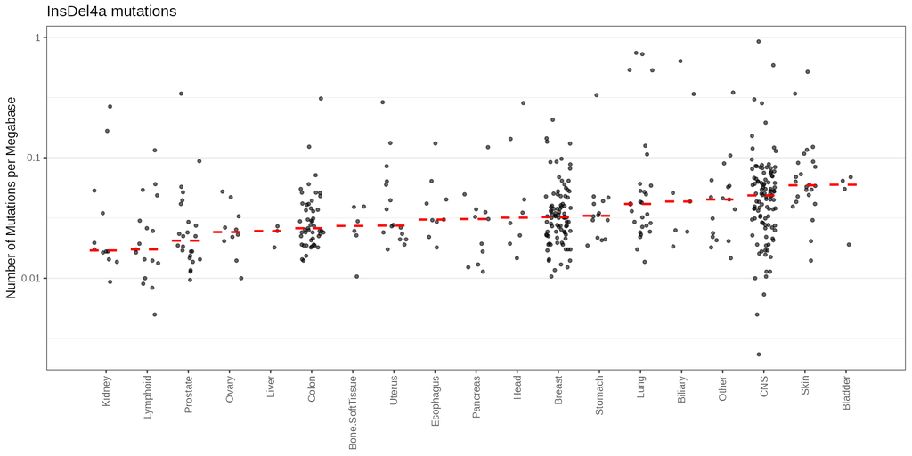

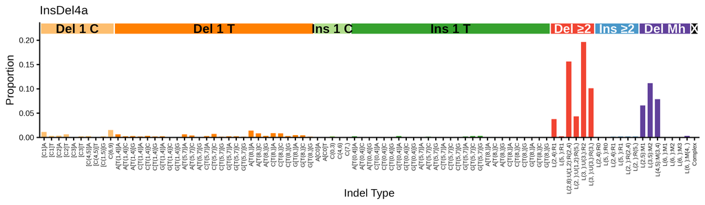

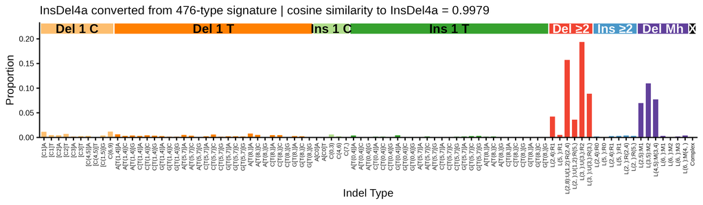

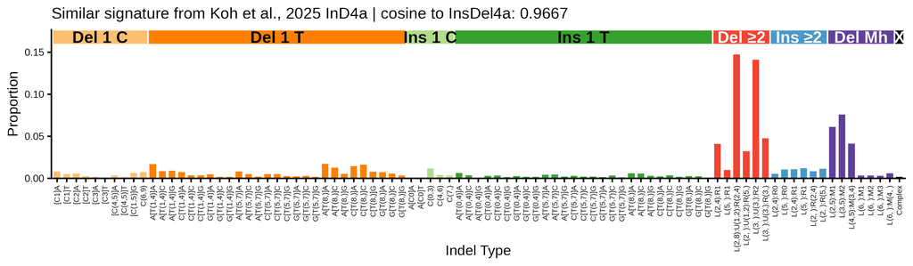

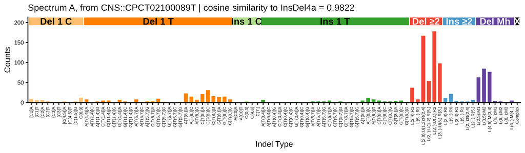

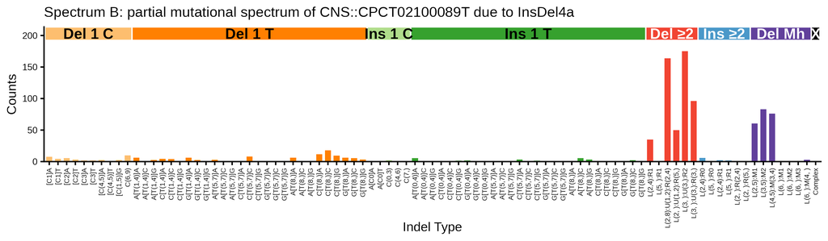

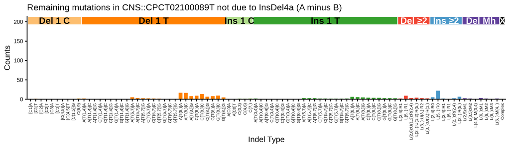

## 476-type representations corresponding to InsDel4a

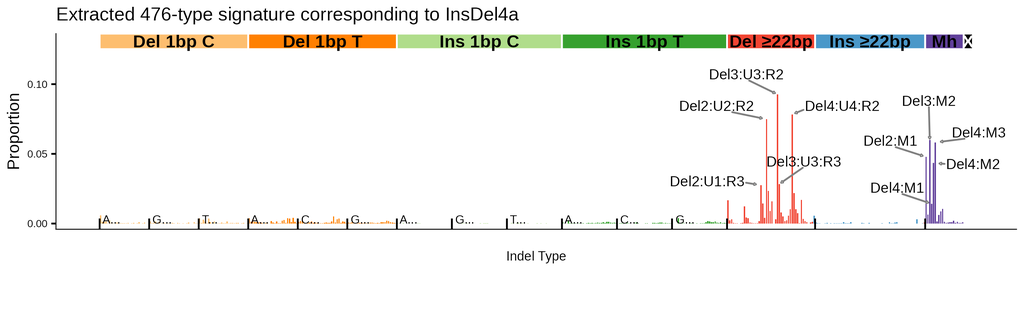

476-type spectrum of the supporting tumor CNS::CPCT02100089T; cosine similarity to the extracted 476-type signature is 0.9599

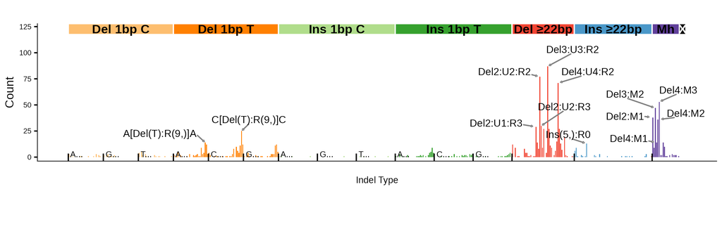

## 83-type signature corresponding to InsDel4a ( C_ID4 )

**Click here to show 83-type plots**

**Note**

WARNING: The 83-type ID_4 extraction excluded the large proportion of T insertions in long poly-T contexts that were detected in extractions of InsDel4b in the 89-type and 476-type classifications. These single T insertions were not extracted in the 89-type and 476-type InsDel4a signature. Thus, C_ID4 corresponds more closely to InsDel4a than to InsDel4b

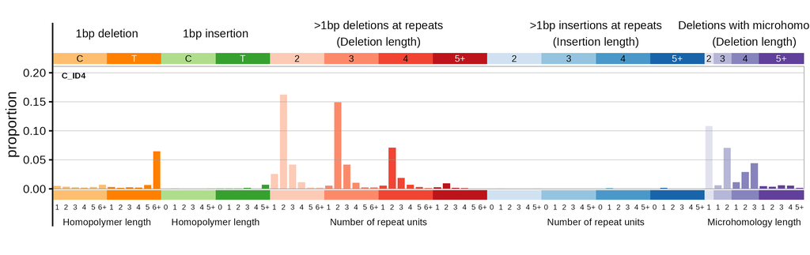

83-type signature converted from 476-type signature corresponding to InsDel4a | cosine similarity to C_ID4: 0.9394

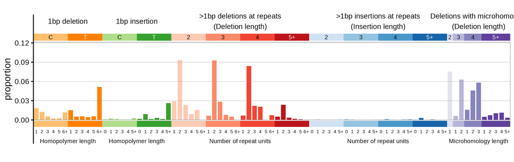

83-type spectrum of the supporting tumor CNS::CPCT02100089T | cosine similarly to C_ID4: 0.8226

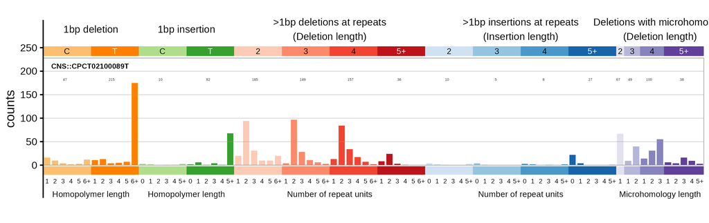

### Similar COSMIC signatures

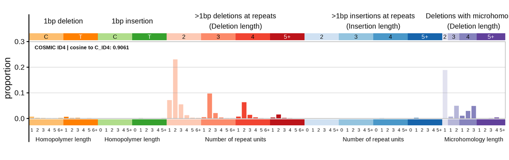